# Linked List

Bahasa pemrograman python telah menyediakan type data yang dinamis, yaitu List. Ukuran dari variabel yang bertipe data list dapat diatur sesuai dengan keinginan programmer selama program dijalankan, tidak harus mempunyai ukuran tetap di awal. Tipe data ini juga menyediakan method menambah data pada saat diperlukan, sehingga tipe data ini bersifat dinamis. Akan tetapi tidak semua pemrograman menyediakan type data seperti ini, oleh karena itu terdapat suatu struktur data yang dapat dibuat oleh programmer yang bersifat dinamis, yaitu Linked List.

Lima hal utama yang terdapat pada struktur data linked list:

1. Node
2. Linked List
3. Penambahan Data pada Linked List
4. Traversal Linked List
5. Ordered List

# Node

Data di dalam memory berada di alamat yang berbeda-beda, jika dibutuhkan agar data-data tersebut dapat terhubung satu sama lain, maka informasi tambahan yang menunjukkan alamat data berikutnya sangatlah diperlukan, seperti yang terlihat pada Gambar 1 berikut.

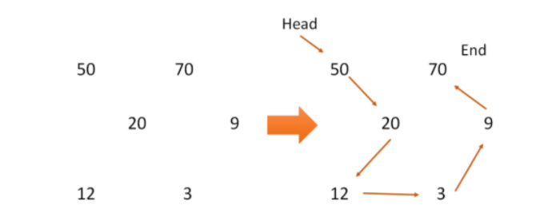

Oleh karena itu data berikutnya dapat diketahui dengan cari mengikuti informasi link yang terdapat

pada informasi tambahan tersebut. Lokasi data pertama dari linked list haruslah diketahui secara eksplisit, sehingga dari data pertama tersebut, data kedua data ditemukan, data ketiga, dan seterusnya. Informasi yang menunjuk pada lokasi data pertama atau head of the list tersebut disebut dengan external reference. Begitu juga dengan data terakhir, harus ada informasi yang menunjukkan bahwa data tersebut adalah data terakhir di dalam linked list, tidak ada lagi data berikutnya.

Untuk membuat struktur data linked list, terlebih dahulu dibuat node-node penyusun linked list tersebut. Node ini harus memiliki setidaknya dua informasi, yaitu informasi mengenai data atau nilai, dan informasi mengenai node berikutnya. Oleh karena itu node dibuat menjadi sebuah tipe data baru yang bertipe class, dengan dua informasi yaitu data dan next.

Terdapat beberapa method penting pada class node ini, antara lain:

1. constructor, yang akan dijalankan setiap instansiasi class
2. getData, untuk mengetahui informasi data yang terdapat pada node tersebut
3. getNext, untuk mengetahui informasi node berikutnya, jika tidak ada node berikutnya maka nilai balik berupa None
4. setData, untuk merubah informasi data yang terdapat pada node tersebut
5. setNext, untuk menentukan node berikutnya yang ditunjukan oleh informasi next dari node tersebut Contoh Node dapat dilihat pada Gambar 2.

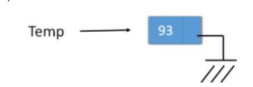

Gambar 2. Node dengan nilai '93' Pada Gambar 2 tersebut, terdapat dua informasi yang terkandung di dalam node, yaitu data dari node adalah 93, dan node tersebut menunjuk ke Nil atau Ground atau tidak ada node yang ditunjuk.

Code

Berikut adalah pembuatan class Node yang merupakan representasi dari sebuah node. Property atau state yang terdapat pada class Node ini :

1. data : berisi nilai dari node
2. next : berisi informasi berikutnya yang ditunjuk oleh node. Proses intansiasi, property next ini diset None yang merupakan representasi Nil atau Ground, berarti tidak ada node yang ditunjuk oleh node ini

```python
class Node:

    def __init__(self, init_data):

        self.data = init_data
        self.next = None

    def getData(self):

        return self.data

    def getNext(self):

        return self.next

    def setData(self, newdata):

        self.data = newdata

    def setNext(self, new_next):

        self.next = new_next
```

```python
a=Node(93)
b=Node(20)
print(a.getNext())
print(b.getNext())
a.setNext(b)
print(a.getNext())
```

```
None
None
<__main__.Node object at 0x0000026AAB971310>
```

Pada code diatas, terdapat obyek a dan obyek b yang memiliki tipe data class Node . Pada saat instansiasi, property data kedua obyek ini bernilai 93 dan 20 , serta property next bernilai None. Pada baris kelima, terdapat perintah a.setNext(b) , yang berarti property next dari obyek a akan menunjuk ke obyek b . Sehingga ketika dilakukan perintah print(a.getNext()) akan menunjukkan ke suatu class Node.

# Linked List Class

Linked list merupakan kumpulan dari node-node yang terhubung satu sama lain. Untuk mengakses node-node yang terdapat pada linked list tersebut, haruslah diketahui terlebih dahulu lokasi node pertama dari suatu linked list, sehingga diperlukan pointer tambahan untuk menunjukkan keberadaan node pertama.

Code Berikut adalah class untuk linked list, dimana pada class tersebut terdapat pointer yang menunjukkan node pertama dari suatu linked list (head). Terdapat dua buah method utama pada class LinkedList ini, antara lain:

1. constructor, **init** , yang merupakan method yang dijalankan pada saat pembuatan obyek. Karena obyek baru pertama kali dibuat, maka linked list masih kosong, sehingga pointer head masih bernilai None.
2. Method isEmpty , untuk pengecekan apakah linked list memiliki node ataukah tidak. Jika pointer head masih menunjuk pada None, maka linked list masih tidak memiliki node, sehingga return value adalah True.

```python
class LinkedList:

    def __init__(self):

        self.head = None

    def isEmpty(self):

        return self.head == None
```

```python
mylist=LinkedList()
```

```python
print(mylist.head)
mylist.isEmpty()
```

```
None
```

```
True
```

```python
print(mylist.head)
```

```
None
```

```python
mylist.isEmpty()
```

```
True
```

Obyek mylist yang telah dibuat pada code diatas yang bertipe linked list, adalah linked list yang masih kosong, belum ada node dalam list tersebut, seperti yang ditunjukkan pada Gambar 3.

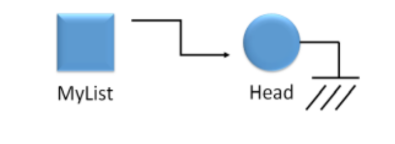

# Penambahan Data pada Linked List

Secara default, penambahan data baru diletakkan pada awal linked list atau yang terdapat pada pointer head. Penambahan data baru ini, dilakukan dengan dua tahapan : Tautkan node baru ini ke node awal dari linked list modifikasi head dari linked list agar menunjuk pada node baru ini, seperti yang ditunjukkan pada Gambar 4 berikut :

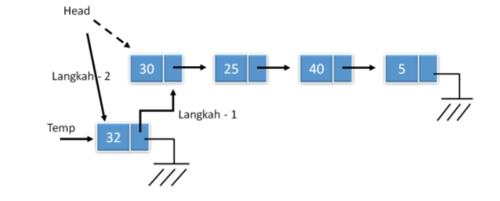

Urutan tahapan ini tidak boleh dibalik, karena jika dibalik maka linked list yang awal tidak lagi dapat ditemukan seperti yang terdapat pada Gambar 5 berikut :

[figure not shown]

# Code

Berikut adalah penambahan method add() pada class LinkedList. Seperti yang dijelaskan sebelumnya, penambahan node baru harus dilakukan dengan urutan yang tepat, yaitu:

temp=Node(item) #temp adalah node baru yang akan ditambahkan temp.setNext(self.head) #pointer Next dari node temp menunjuk pada node yang ditunjuk oleh pointer head self.head=temp #pointer head menunjuk pada node temp yang sudah tersambu ng dengan linked list

```python
class LinkedList:

    def __init__(self):

        self.head = None

    def isEmpty(self):

        return self.head == None

    def add(self, item):

        temp = Node(item)

        temp.setNext(self.head)

        self.head = temp
```

```python
mylist=LinkedList()
```

```python
print(mylist.head)
mylist.isEmpty()
```

```
None
```

```
True
```

```python
mylist.add(34)
print(mylist.head)
```

```
<__main__.Node object at 0x0000026AAB9716D0>
```

```python
mylist.add(45)
print(mylist.head)
print(mylist.head.data)
```

```
<__main__.Node object at 0x0000026AABAB2D70>
45
```

# Traversal Linked List

Untuk mengetahui ukuran dari list, diperlukan tahapan traverse, yaitu menelusuri setiap node yang terdapat pada linked list, seperti pada Gambar 6 sebagai berikut :

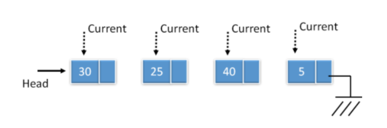

Pada proses penelusuran atau traversal dibutuhkan pointer bantuan. Pointer bantuan yang ditunjukkan pada Gambar 6 tersebut, adalah pointer curent yang bergerak dari node awal sampai dengan node akhir. Proses traversal ini dibutuhkan untuk beberapa hal, seperti untuk menghitung jumlah node yang terdapat pada Linked List, untuk mencari node pada linked list, untuk menampilkan seluruh node dari linked list, untuk menyisipkan node setelah atau sebelum node yang sudah terdapat pada linked list, dan untuk menghapus suatu node.

Code Implementasi pertama yang dibuat adalah pembuatan method size(), untuk menghitung jumlah node. Pada method size terdapat beberapa tahapan :

1. pointer bantuan curent berada pada node yang ditunjuk oleh head (yaitu node pertama)
2. pointer curent bergerak, dengan perintah curent=curent.getNext() , sekaligus dilakukan increment variabel count, yang merepresentasikan jumlah node
3. pergerakan atau traversal ini akan berakhir ketika pointer curent menunjuk pada None, yang merepresentasikan, tidak ada lagi node yang terdapat pada Linked list

```python
class LinkedList:

    def __init__(self):

        self.head = None

    def isEmpty(self):

        return self.head == None

    def add(self, item):

        temp = Node(item)

        temp.setNext(self.head)

        self.head = temp

    def size(self):

        current = self.head
        count = 0

        while current != None:

            count = count + 1
            current = current.getNext()

        return count
```

```python
# Berikut contoh penggunaan method size() pada class LinkedList

mylist=LinkedList()
mylist.add(45)
mylist.add(34)
mylist.add(70)
print(mylist.size())
```

```
3
```

# Pencarian Node pada Linked List

Untuk pencarian node di dalam linked list juga perlu dilakukan traverse linked list seperti sebelumnya, hanya saja setiap berada pada suatu node, maka dilakukan pencocokan apakah node tersebut adalah node yang dicari, seperti Gambar 7 berikut:

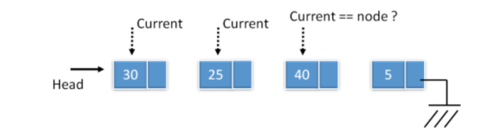

Gambar 7. Pencarian Node pada Linked List Seperti halnya pada method sebelumnya, terdapat pointer curent yang bergerak dari awal sampai akhir, hanya saja diperlukan pencocokan antara data yang terdapat pada curent dengan data yang dicari. Implementasi pencarian dapat dilihat pada method berikut

Code Berikut penambahan method search() pada class LinkedList. Method search() ini hampir sama dengan method size , hanya saja jika ditambahkan apakah node yang ditunjukkan oleh pointer curent adalah node yang dicari, dengan perintah: if curent.getData() == item: #dimana item adalah node yang dicari maka method ini akan menghasilkan nilai True.

```python
class LinkedList:

    def __init__(self):

        self.head = None

    def isEmpty(self):

        return self.head == None

    def add(self, item):

        temp = Node(item)

        temp.setNext(self.head)

        self.head = temp

    def size(self):

        current = self.head
        count = 0

        while current != None:

            count = count + 1
            current = current.getNext()

        return count

    def search(self, item):

        current = self.head
        found = False

        while current != None and not found:

            if current.getData() == item:
                found = True

            else:
                current = current.getNext()

        return found
mylist=LinkedList()
mylist.add(45)
mylist.add(34)
mylist.add(70)
mylist.add(84)
mylist.size()
mylist.search(34)
```

```
True
```

Menampilkan seluruh data pada Linked list Proses traversal juga dapat digunakan untuk menampilkan data pada seluruh node yang terdapat pada Linked List.

Code

Berikut method display() untuk menampilkan data dari seluruh node pada linked list

```python
class LinkedList:

    def __init__(self):

        self.head = None

    def isEmpty(self):

        return self.head == None

    def add(self, item):

        temp = Node(item)

        temp.setNext(self.head)

        self.head = temp

    def size(self):

        current = self.head
        count = 0

        while current != None:

            count = count + 1
            current = current.getNext()

        return count

    def search(self, item):

        current = self.head
        found = False

        while current != None and not found:

            if current.getData() == item:
                found = True

            else:
                current = current.getNext()

        return found

    def display(self):

        current = self.head

        while current != None:

            print(current.getData())

            current = current.getNext()
mylist=LinkedList()
mylist.add(45)
mylist.add(34)
mylist.add(70)
mylist.add(84)

mylist.display()
```

```
84
70
34
45
```

# Penghapusan Node pada Linked List

Penghapusan data (remove data) dilakukan dengan dua tahapan yaitu :

1. traverse linked list, untuk mencari node mana yang akan dihapus
2. remove data, menghapus node dari linked list

Untuk traverse linked list sama hal nya dengan method sebelumnya, yaitu terdapat pointer curent yang menelusuri node awal sampai dengan node akhir untuk mencari node yang akan dihapus. Ketika node sudah ditemukan, penghapusan tidak dapat dilakukan langsung begitu saja, karena di dalam node terdapat informasi lain, yaitu next yang menunjukkan lokasi node berikutnya. Sebelum dilakukan penghapusan perlu dilakukan terlebih dahulu pentautan antara node sebelum node yang dicari dengan node sesudah node yang dicari, sehingga node yang dicari dapat dihapus. Oleh karena itu diperlukan pointer tambahan selain curent, yaitu pointer previous. Pointer ini bergerak satu langkah sebelum pointer curent, sehingga ketika pointer curent sudah menemukan data yang dicari, maka pointer previous ini dapat ditautkan dengan node sesudah curent. Ilustrasi ketika data yang akan dihapus berada di tengah linked list ditunjukkan pada Gambar 8.

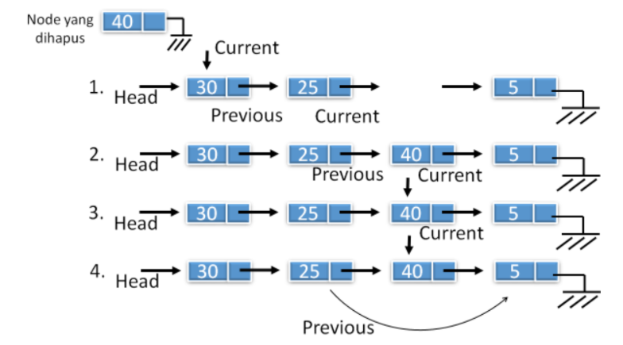

Jika data yang dihapus berada di node awal dari linked list (yang ditunjukkan dengan nilai previous masih None, maka yang dilakukan pointer head langsung menunjuk pada node setelah node yang akan dihapus tersebut, seperti Gambar 9 berikut:

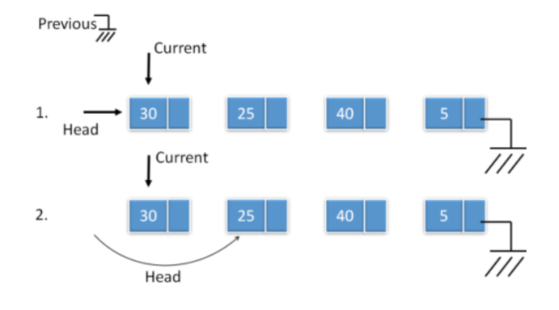

Berikut adalah penambahan method remove() untuk menghapus node yang diinginkan pada linked list

```python
class LinkedList:

    def __init__(self):

        self.head = None

    def isEmpty(self):

        return self.head == None

    def add(self, item):

        temp = Node(item)

        temp.setNext(self.head)

        self.head = temp

    def size(self):

        current = self.head
        count = 0

        while current != None:

            count = count + 1
            current = current.getNext()

        return count

    def search(self, item):

        current = self.head
        found = False

        while current != None and not found:

            if current.getData() == item:
                found = True

            else:
                current = current.getNext()

        return found

    def display(self):

        current = self.head

        while current != None:

            print(current.getData())

            current = current.getNext()

    def remove(self, item):

        current = self.head
        previous = None
        found = False

        while not found:

            if current.getData() == item:
                found = True

            else:
                previous = current
                current = current.getNext()

        if previous == None:
            self.head = current.getNext()

        else:
            previous.setNext(current.getNext())
```

```python
# Berikut adalah contoh penggunaan method remove()

mylist=LinkedList()
mylist.add(45)
mylist.add(34)
mylist.add(70)
mylist.add(84)
mylist.add(97)
mylist.display()

mylist.remove(34)
```

```
97
84
70
34
45
```

```python
mylist.display()
```

```
97
84
70
45
```

# Ordered List

Proses pencarian pada linked list sebelumnya dilakukan dengan cara mencari node satu persatu sampai node terakhir. Proses pencarian ini akan menjadi lebih cepat jika data sudah dalam keadaan terurut, sehingga pencarian dapat dihentikan ketika ditemukan node dengan data lebih rendah atau lebih tinggi. Class Ordered List akan memudahkan pencarian suatu node, karena data yang terdapat pada class ini sudah dalam keadaan terurut. Method yang terdapat pada ordered list, sama halnya dengan class linkedlist, hanya saja terdapat perbedaan pada method untuk add data (karena node yang terbentuk harus dalam keadaan terurut), dan method search data.

Code

Berikut method untuk class ordered list

```python
class OrderedLinkedList:

    def __init__(self):

        self.head = None

    def isEmpty(self):

        return self.head == None

    def size(self):

        current = self.head
        count = 0

        while current != None:

            count = count + 1
            current = current.getNext()

        return count

    def display(self):

        current = self.head

        while current != None:

            print(current.getData())

            current = current.getNext()

    def remove(self, item):

        current = self.head
        previous = None
        found = False

        while not found:

            if current.getData() == item:
                found = True

            else:
                previous = current
                current = current.getNext()

        if previous == None:
            self.head = current.getNext()

        else:
            previous.setNext(current.getNext())

    def search(self, item):

        current = self.head
        found = False
        stop = False

        while current != None and not found and not stop:

            if current.getData() == item:
                found = True

            else:
                if current.getData() > item:
                    stop = True

                else:
                    current = current.getNext()

        return found

    def add(self, item):

        current = self.head
        previous = None
        stop = False

        while current != None and not stop:

            if current.getData() > item:
                stop = True

            else:
                previous = current
                current = current.getNext()

        temp = Node(item)

        if previous == None:

            temp.setNext(self.head)
            self.head = temp

        else:   # ditautkan antara previous dengan current

            temp.setNext(current)
            previous.setNext(temp)
```

```python
# Berikut adalah contoh penggunaan class ordered Linked List

myList=OrderedLinkedList()
myList.add(9)
myList.add(14)
myList.display()
```

```
9
14
```

```python
myList.add(100)
myList.display()
```

```
9
14
100
```